# R 패키지 ggplot2의 이해

## 6. Trellis graphics

- Trellis란 정원에 장미 덩굴 등을 올리기 위한 격가 모양의 틀로 다차원의 데이터를 disply하기 위한 일종의 framework임
- 다차원의 데이터를 2차원으로 표현하는데 있어 조건(R의 factor 레벨)으로 격자를 이룬 후 같은 스케일로 동일한 그래프를 고려 비교하는 것이 특징임
- `ggplot2` 패키지에서는 **facet** 계열 명령어를 통해 Trellis display를 구현할 수 있음

### 6.1 `facet_wrap` / `facet_grid` example

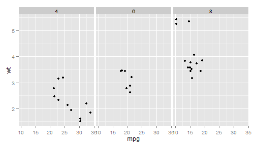

```r
p.tmp <- ggplot(mtcars, aes(mpg, wt)) + geom_point()
p.tmp + facet_wrap(~cyl)
```

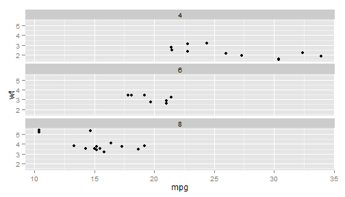

```r
p.tmp + facet_wrap(~cyl, nrow = 3)
```

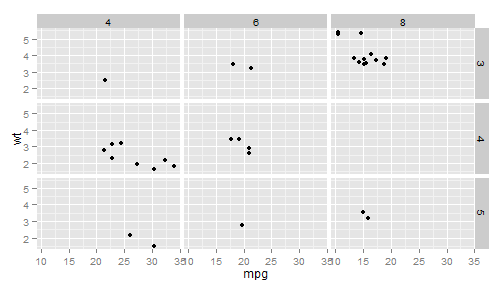

```r
p.tmp + facet_grid(gear ~ cyl)
```

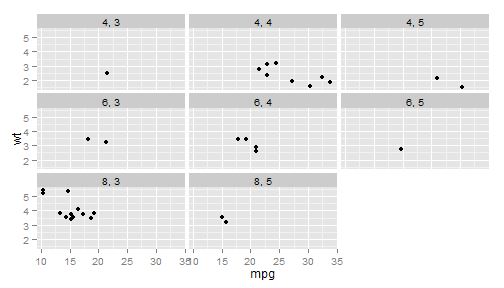

```r
p.tmp + facet_wrap(~cyl + gear)
```

### 6.2 controlling scales in facets (default: `scales="ﬁxed"`)

- `ggplot2`에서는 전통적인 Trellis와는 달리 scale을 데이터 분포에 따라 변경하는 것임
- 기본적으로는 **facet**은 `scales="fixed"`가 사용됨

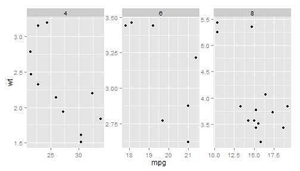

```r
p.tmp + facet_wrap(~cyl, scales = "free")
```

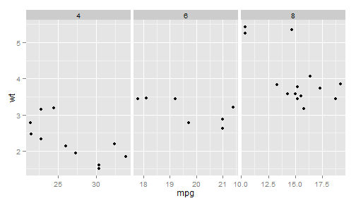

```r
p.tmp + facet_wrap(~cyl, scales = "free_x")
```

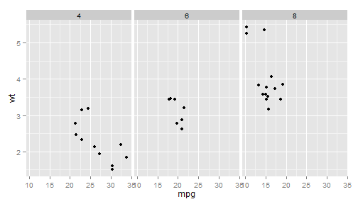

```r
p.tmp + facet_wrap(~cyl, scales = "fixed")
```

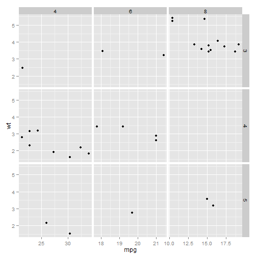

```r
# contstraint on facet_grid (all rows,columns same scale)
p.tmp + facet_grid(gear ~ cyl, scales = "free_x")
```

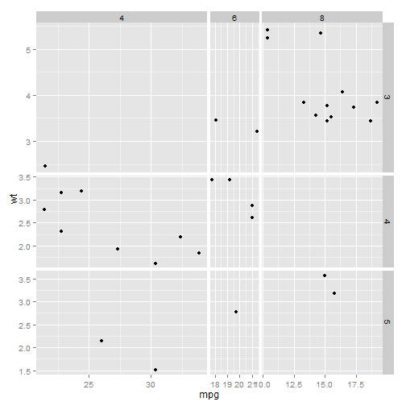

```r
p.tmp + facet_grid(gear ~ cyl, scales = "free", space = "free")
```